# Project: Investigation of a No Show appointment Dataset

- Introduction
- Data Wrangling
- Exploratory Data Analysis
- Conclusion

## Introduction

This dataset has information from over 100k medical appointments in Brazil and is focused on the question of no show appointments of patients for their appointment. There are many attributes about the patient are included in this dataset.This project aims to investigate this dataset and give insight on the correlation of the attributes provided.

I will be looking at the following questions:

- No show appointment is more in which age group
- Which Gender has the most no show for appointment
- Which appointment day has most No Show appointment
- which neighbourhood had the most No Show appointment
- The correlation of Patients conditions or sickness with No show appointment
- Percentage of Female and Male Gender in the Dataset

Columns of the dataset According to the dataset description, 14 columns of data were recorded as following:

- PatientId : ID of the patient
- AppointmentID : Identification of each appointment
- Gender : Male or Female .
- ScheduledDay : The day someone called or booked the appointment.
- AppointmentDay : The day of the actual appointment.
- Age : How old is the patient took place.
- Scholarship : Brazilian bursary to poor families.
- Hipertension : Condition if patient suffers from high blood pressure.
- Diabetes : Condition if patient is diabetes.
- Alcoholism : Condition If patient is considered alcoholic.
- Handcap : Condition if patient has disability(ies),level of disability from 0 to 5 is recorded
- SMS_received : Number of SMS messages sent to patient.
- No-show : Condition if the patient didn't show, Yes means the patient did not show and vice versa

```python
# load packages and data for this project
import pandas as pd
import numpy as np
import seaborn as sns
import matplotlib.pyplot as plt
%matplotlib inline
df = pd.read_csv("Database_No_show_appointments/noshowappointments-kagglev2-may-2016.csv")
```

## Data Wrangling

In this section, I will check the data for cleanliness, clean the data for further analyis.

```python
# I will view my data to see what changes to be made to clean it
# first, let me view a few rows and columns of this data

df.head(5)
```

|  | PatientId | AppointmentID | Gender | ScheduledDay | AppointmentDay | Age | Neighbourhood | Scholarship | Hipertension | Diabetes | Alcoholism | Handcap | SMS_received | No-show |
| --- | --- | --- | --- | --- | --- | --- | --- | --- | --- | --- | --- | --- | --- | --- |
| 0 | 2.987250e+13 | 5642903 | F | 2016-04-29T18:38:08Z | 2016-04-29T00:00:00Z | 62 | JARDIM DA PENHA | 0 | 1 | 0 | 0 | 0 | 0 | No |
| 1 | 5.589978e+14 | 5642503 | M | 2016-04-29T16:08:27Z | 2016-04-29T00:00:00Z | 56 | JARDIM DA PENHA | 0 | 0 | 0 | 0 | 0 | 0 | No |
| 2 | 4.262962e+12 | 5642549 | F | 2016-04-29T16:19:04Z | 2016-04-29T00:00:00Z | 62 | MATA DA PRAIA | 0 | 0 | 0 | 0 | 0 | 0 | No |
| 3 | 8.679512e+11 | 5642828 | F | 2016-04-29T17:29:31Z | 2016-04-29T00:00:00Z | 8 | PONTAL DE CAMBURI | 0 | 0 | 0 | 0 | 0 | 0 | No |
| 4 | 8.841186e+12 | 5642494 | F | 2016-04-29T16:07:23Z | 2016-04-29T00:00:00Z | 56 | JARDIM DA PENHA | 0 | 1 | 1 | 0 | 0 | 0 | No |

```python
# lets see the data shape to see how many rows and columns in it
df.shape
```

```
(110527, 14)
```

```python
#Lets view the data information

df.info()
```

```
<class 'pandas.core.frame.DataFrame'>
RangeIndex: 110527 entries, 0 to 110526
Data columns (total 14 columns):
PatientId         110527 non-null float64
AppointmentID     110527 non-null int64
Gender            110527 non-null object
ScheduledDay      110527 non-null object
AppointmentDay    110527 non-null object
Age               110527 non-null int64
Neighbourhood     110527 non-null object
Scholarship       110527 non-null int64
Hipertension      110527 non-null int64
Diabetes          110527 non-null int64
Alcoholism        110527 non-null int64
Handcap           110527 non-null int64
SMS_received      110527 non-null int64
No-show           110527 non-null object
dtypes: float64(1), int64(8), object(5)
memory usage: 11.8+ MB
```

```python
# lets view the data types
df.dtypes
```

```
PatientId         float64
AppointmentID       int64
Gender             object
ScheduledDay       object
AppointmentDay     object
Age                 int64
Neighbourhood      object
Scholarship         int64
Hipertension        int64
Diabetes            int64
Alcoholism          int64
Handcap             int64
SMS_received        int64
No-show            object
dtype: object
```

```python
#Lets check for unique values in each clolumn
df.nunique()
```

```
PatientId          62299
AppointmentID     110527
Gender                 2
ScheduledDay      103549
AppointmentDay        27
Age                  104
Neighbourhood         81
Scholarship            2
Hipertension           2
Diabetes               2
Alcoholism             2
Handcap                5
SMS_received           2
No-show                2
dtype: int64
```

```python
# Lets check for duplicates
df.duplicated().sum()
```

```
0
```

### Findings from the Dataset

Unique values are expected in this kind of data and I will pay no attention to them.Also, there are no null value,and the data types are appropriate except the scheduledday and appointmentday which need to be changed to day time data type.The patientId and appointmentId are personal information which are not relevant to the analysis.So, I will remove those two columns and change the columns to lower case letters and replace hyphen with underscore.I will also remove rows with zero in age column as there is nothing like zero year.There are no duplicates in the dataset.

### Data Cleaning

Following the findings above, i will drop the patientId and AppointmentID columns, they as is not relevant to my analyis. Also, I will change the column names to small letters and replace the dash in the last column with underscore

```python
# Dropping patientId and AppointmentID columns
df.drop(['PatientId', 'AppointmentID'], axis = 1, inplace = True)
```

```python
#I will change the columns to lower cases and replace the dash with underscore
df.rename(columns=lambda x : x.strip().replace("-","_"),inplace=True)
df=df.rename(columns=str.lower)
```

```python
# lets check validate the changes
df.head()
```

|  | gender | scheduledday | appointmentday | age | neighbourhood | scholarship | hipertension | diabetes | alcoholism | handcap | sms_received | no_show |
| --- | --- | --- | --- | --- | --- | --- | --- | --- | --- | --- | --- | --- |
| 0 | F | 2016-04-29T18:38:08Z | 2016-04-29T00:00:00Z | 62 | JARDIM DA PENHA | 0 | 1 | 0 | 0 | 0 | 0 | No |
| 1 | M | 2016-04-29T16:08:27Z | 2016-04-29T00:00:00Z | 56 | JARDIM DA PENHA | 0 | 0 | 0 | 0 | 0 | 0 | No |
| 2 | F | 2016-04-29T16:19:04Z | 2016-04-29T00:00:00Z | 62 | MATA DA PRAIA | 0 | 0 | 0 | 0 | 0 | 0 | No |
| 3 | F | 2016-04-29T17:29:31Z | 2016-04-29T00:00:00Z | 8 | PONTAL DE CAMBURI | 0 | 0 | 0 | 0 | 0 | 0 | No |
| 4 | F | 2016-04-29T16:07:23Z | 2016-04-29T00:00:00Z | 56 | JARDIM DA PENHA | 0 | 1 | 1 | 0 | 0 | 0 | No |

```python
#Lets rename Columns hipertension and handcap to hypertention and handicap
df.rename(columns ={'hipertension': 'hypertension','handcap': 'handicap'}, inplace = True)
```

```python
# Lets confirm changes above
df.head()
```

|  | gender | scheduledday | appointmentday | age | neighbourhood | scholarship | hypertension | diabetes | alcoholism | handicap | sms_received | no_show |
| --- | --- | --- | --- | --- | --- | --- | --- | --- | --- | --- | --- | --- |
| 0 | F | 2016-04-29T18:38:08Z | 2016-04-29T00:00:00Z | 62 | JARDIM DA PENHA | 0 | 1 | 0 | 0 | 0 | 0 | No |
| 1 | M | 2016-04-29T16:08:27Z | 2016-04-29T00:00:00Z | 56 | JARDIM DA PENHA | 0 | 0 | 0 | 0 | 0 | 0 | No |
| 2 | F | 2016-04-29T16:19:04Z | 2016-04-29T00:00:00Z | 62 | MATA DA PRAIA | 0 | 0 | 0 | 0 | 0 | 0 | No |
| 3 | F | 2016-04-29T17:29:31Z | 2016-04-29T00:00:00Z | 8 | PONTAL DE CAMBURI | 0 | 0 | 0 | 0 | 0 | 0 | No |
| 4 | F | 2016-04-29T16:07:23Z | 2016-04-29T00:00:00Z | 56 | JARDIM DA PENHA | 0 | 1 | 1 | 0 | 0 | 0 | No |

```python
#check age column for age less than 0
df.query('age==0').count()
```

```
gender            3539
scheduledday      3539
appointmentday    3539
age               3539
neighbourhood     3539
scholarship       3539
hypertension      3539
diabetes          3539
alcoholism        3539
handicap          3539
sms_received      3539
no_show           3539
dtype: int64
```

```python
#Remove rows with zero in age column
df = df[df.age != 0]
```

```python
#Confirm changes above
df.query('age==0').count()
```

```
gender            0
scheduledday      0
appointmentday    0
age               0
neighbourhood     0
scholarship       0
hypertension      0
diabetes          0
alcoholism        0
handicap          0
sms_received      0
no_show           0
dtype: int64
```

```python
#New shape of the dataset
df.shape
```

```
(106988, 12)
```

```python
# change date columns to datetime datatype
df['scheduledday']=pd.to_datetime(df['scheduledday'],utc=False).dt.normalize()
df['appointmentday']=pd.to_datetime(df['appointmentday'],utc=False).dt.normalize()
```

```python
#lets validate the channges above
df.info()
```

```
<class 'pandas.core.frame.DataFrame'>
Int64Index: 106988 entries, 0 to 110526
Data columns (total 12 columns):
gender            106988 non-null object
scheduledday      106988 non-null datetime64[ns]
appointmentday    106988 non-null datetime64[ns]
age               106988 non-null int64
neighbourhood     106988 non-null object
scholarship       106988 non-null int64
hypertension      106988 non-null int64
diabetes          106988 non-null int64
alcoholism        106988 non-null int64
handicap          106988 non-null int64
sms_received      106988 non-null int64
no_show           106988 non-null object
dtypes: datetime64[ns](2), int64(7), object(3)
memory usage: 10.6+ MB
```

```python
#Lets validate the change in date by viewing few head rows and columns
df.head()
```

|  | gender | scheduledday | appointmentday | age | neighbourhood | scholarship | hypertension | diabetes | alcoholism | handicap | sms_received | no_show |
| --- | --- | --- | --- | --- | --- | --- | --- | --- | --- | --- | --- | --- |
| 0 | F | 2016-04-29 | 2016-04-29 | 62 | JARDIM DA PENHA | 0 | 1 | 0 | 0 | 0 | 0 | No |
| 1 | M | 2016-04-29 | 2016-04-29 | 56 | JARDIM DA PENHA | 0 | 0 | 0 | 0 | 0 | 0 | No |
| 2 | F | 2016-04-29 | 2016-04-29 | 62 | MATA DA PRAIA | 0 | 0 | 0 | 0 | 0 | 0 | No |
| 3 | F | 2016-04-29 | 2016-04-29 | 8 | PONTAL DE CAMBURI | 0 | 0 | 0 | 0 | 0 | 0 | No |
| 4 | F | 2016-04-29 | 2016-04-29 | 56 | JARDIM DA PENHA | 0 | 1 | 1 | 0 | 0 | 0 | No |

```python
#Lets validate the change in date by viewing few tail rows and columns
df.tail()
```

|  | gender | scheduledday | appointmentday | age | neighbourhood | scholarship | hypertension | diabetes | alcoholism | handicap | sms_received | no_show |
| --- | --- | --- | --- | --- | --- | --- | --- | --- | --- | --- | --- | --- |
| 110522 | F | 2016-05-03 | 2016-06-07 | 56 | MARIA ORTIZ | 0 | 0 | 0 | 0 | 0 | 1 | No |
| 110523 | F | 2016-05-03 | 2016-06-07 | 51 | MARIA ORTIZ | 0 | 0 | 0 | 0 | 0 | 1 | No |
| 110524 | F | 2016-04-27 | 2016-06-07 | 21 | MARIA ORTIZ | 0 | 0 | 0 | 0 | 0 | 1 | No |
| 110525 | F | 2016-04-27 | 2016-06-07 | 38 | MARIA ORTIZ | 0 | 0 | 0 | 0 | 0 | 1 | No |
| 110526 | F | 2016-04-27 | 2016-06-07 | 54 | MARIA ORTIZ | 0 | 0 | 0 | 0 | 0 | 1 | No |

The data has been cleaned and ready to be explored in the next chapter

## Exploratory Data Analysis

Here we will explore the cleaned data to gain insight on the correlation of the attributes.

```python
#Lets use decribe function to view important aggregate values
df.describe()
```

|  | age | scholarship | hypertension | diabetes | alcoholism | handicap | sms_received |
| --- | --- | --- | --- | --- | --- | --- | --- |
| count | 106988.000000 | 106988.00000 | 106988.000000 | 106988.000000 | 106988.000000 | 106988.000000 | 106988.000000 |
| mean | 38.315718 | 0.10103 | 0.203771 | 0.074242 | 0.031405 | 0.022975 | 0.323261 |
| std | 22.466431 | 0.30137 | 0.402802 | 0.262165 | 0.174412 | 0.164114 | 0.467723 |
| min | -1.000000 | 0.00000 | 0.000000 | 0.000000 | 0.000000 | 0.000000 | 0.000000 |
| 25% | 19.000000 | 0.00000 | 0.000000 | 0.000000 | 0.000000 | 0.000000 | 0.000000 |
| 50% | 38.000000 | 0.00000 | 0.000000 | 0.000000 | 0.000000 | 0.000000 | 0.000000 |
| 75% | 56.000000 | 0.00000 | 0.000000 | 0.000000 | 0.000000 | 0.000000 | 1.000000 |
| max | 115.000000 | 1.00000 | 1.000000 | 1.000000 | 1.000000 | 4.000000 | 1.000000 |

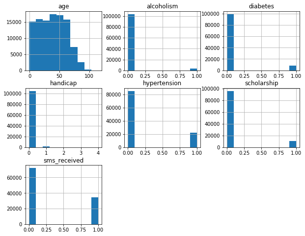

```python
#plot histogram distribution
df.hist(figsize=(10,8)) ;
```

From the histogram above, the age histogram is skewed to the right,with more average age of 40-50 people involved.Also, less patients with diabetes,handicap,alcohol,and those with scholarship were involved.There are more people with hypertension,over 30k sms were received prior to appointment day.

## Research Question 1:No show appointment is more in which age group

```python
# create not attended data frame
notattended=df.query('no_show=="Yes"')
```

```python
# Create attended data frame
attended=df.query('no_show=="No"')
```

```python
# Get the average age of notattended and attended
mean_age_notattended=notattended['age'].mean()
mean_age_attended=attended['age'].mean()
```

```python
#Print output
mean_age_notattended,mean_age_attended
```

```
(35.329151291512915, 39.074717494256106)
```

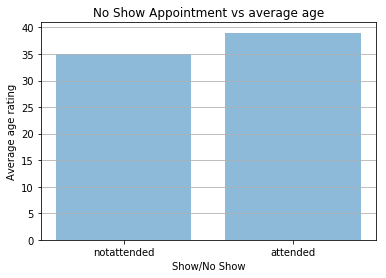

```python
# Create a bar chart with Attended/Notattended vs Average age

data=['notattended','attended']
plt.xticks([1,2], data)
x_pos = [1, 2]
heights = [35,39]
plt.bar(x_pos, heights,alpha=0.5)
plt.title('No Show Appointment vs average age')
plt.xlabel('Show/No Show')
plt.ylabel('Average age rating')
plt.grid(axis='y')
plt.show();
```

matplotlib was used to obtain the graph above. From above bars, avarage age of those that did not show for their appointment is within 35, while more of the people 40 and above attended their appointments.Also, more of the middle age group were involved in this research as seen from the above .

## Research Question 2:Which Gender has the most no show for appointment

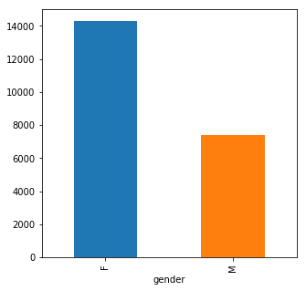

```python
# Plot a barchart of gender vs No show count from notattended dataframe
notattended.groupby(['gender'])['no_show'].count().plot(kind='bar',figsize=(5,5));
```

From the above bar chart, more of the female gender(about 14K) did not attend their appointment, while about half of that of men did not attend their appointment.

## Research Question 3: Which appointment day has most no Show appointment

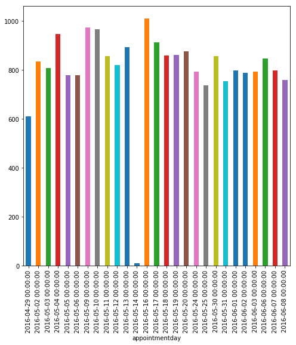

```python
notattended.groupby(['appointmentday'])['no_show'].count().plot(kind='bar',figsize=(8,8));
```

From the above,no show appointment was most on 2016-05-16, and about 1000 no show appointment was recorded.

## Research Question 4:Which neighbourhood had the most No Show appointment

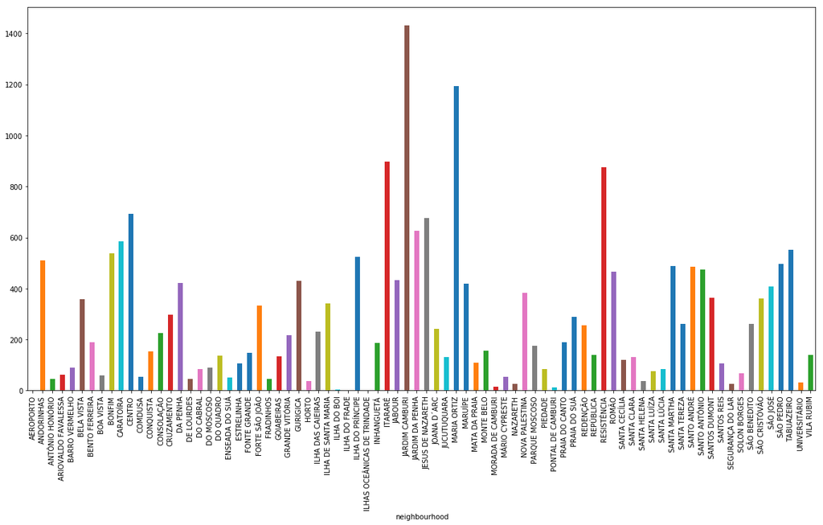

```python
# Lets visualize the neighbourhood count for  not attended appointments
notattended.groupby(['neighbourhood'])['no_show'].count().plot(kind='bar',figsize=(20,10));
```

From the above bars, Jardim Camburi neighbourhod had the most not-attended appointment, about 1450 appointments were not attended to.We will be looking at correlation of the patient's sickness,scholarship, and sms_received with No Show appointments below

## Research Question 5:The correlation of Patients condition or sickness with No show appointmen

### Handicap vs No Show Appointment

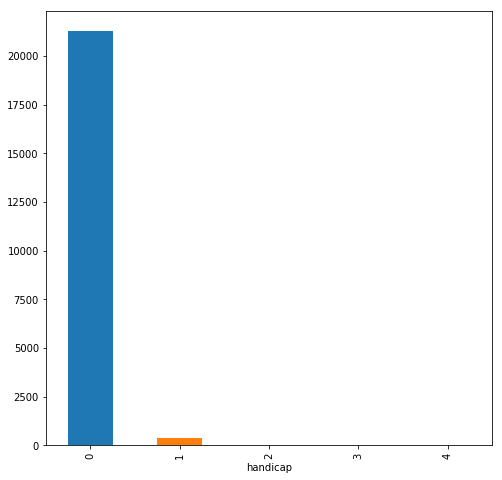

```python
#bar chart of handicap vs not attended appointments
notattended.groupby(['handicap'])['no_show'].count().plot(kind='bar', figsize=(8,8));
```

### Hypertension vs No Show Appointment

```python
#Lets get the number of patients with hypertention that did not attend appointments
num_with_hyp=notattended['hypertension'].value_counts()[1]
```

```python
#lets get the num of patiets without hypertension that did not attended
num_without_hyp=notattended['hypertension'].value_counts()[0]
```

```python
#lets get Print the number with and without hypertension that did not attend
num_with_hyp,num_without_hyp
```

```
(3772, 17908)
```

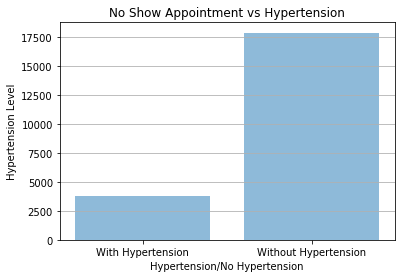

```python
#Plot a bar chart of hypertension Vs No Hypertension that missed their appointments
data=['With Hypertension','Without Hypertension']
plt.xticks([1,2], data)
x_pos = [1, 2]
heights = [3772,17908]
plt.bar(x_pos, heights,alpha=0.5)
plt.title('No Show Appointment vs Hypertension')
plt.xlabel('Hypertension/No Hypertension')
plt.ylabel('Hypertension Level')
plt.grid(axis='y')
plt.show();
```

### Diabetes Vs No Show Appointment

```python
#lets get the number of patients with/without diabetes that did not attend appointments
num_with_dia=notattended['diabetes'].value_counts()[1]
num_without_dia=notattended['diabetes'].value_counts()[0]
```

```python
#lets print the output of above command
num_with_dia,num_without_dia
```

```
(1430, 20250)
```

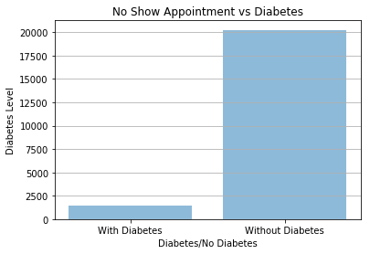

```python
#Plot a bar chart of Diabetes/No Diabetes Vs No Diabetes that did not attend appointment
data=['With Diabetes','Without Diabetes']
plt.xticks([1,2], data)
x_pos = [1, 2]
heights = [1430,20250]
plt.bar(x_pos, heights,alpha=0.5)
plt.title('No Show Appointment vs Diabetes')
plt.xlabel('Diabetes/No Diabetes')
plt.ylabel('Diabetes Level')
plt.grid(axis='y')
plt.show();
```

### Alcoholism Vs No Show Appointment

```python
#Lets get the number of patients with/without alcoholism who missed their appointments
num_with_alc=notattended['alcoholism'].value_counts()[1]
num_without_alc=notattended['alcoholism'].value_counts()[0]
```

```python
#lets print the output of above command
num_with_alc,num_without_alc
```

```
(677, 21003)
```

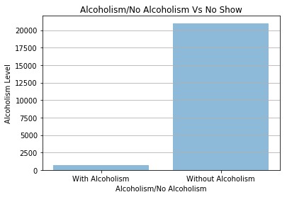

```python
#Plot a bar chart of Alcoholism/No Alcoholism Vs No Diabetes that did not attend appointment
data=['With Alcoholism','Without Alcoholism']
plt.xticks([1,2], data)
x_pos = [1, 2]
heights = [677,21003]
plt.bar(x_pos, heights,alpha=0.5)
plt.title('Alcoholism/No Alcoholism Vs No Show')
plt.xlabel('Alcoholism/No Alcoholism')
plt.ylabel('Alcoholism Level')
plt.grid(axis='y')
plt.show();
```

### Scholarship Vs No Show Appointment

```python
#Lets get the number of patients with/without Scholarship who missed their appointments
num_with_sch=notattended['scholarship'].value_counts()[1]
num_without_sch=notattended['scholarship'].value_counts()[0]
```

```python
#lets print the output of above command
num_with_sch,num_without_sch
```

```
(2571, 19109)
```

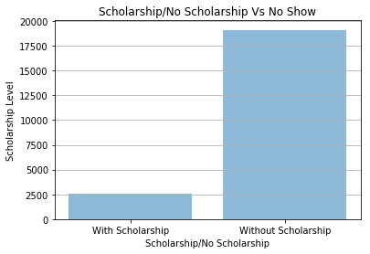

```python
#Plot a bar chart of Scholarship/No Scholarship Vs No Show
data=['With Scholarship','Without Scholarship']
plt.xticks([1,2], data)
x_pos = [1, 2]
heights = [2571,19109]
plt.bar(x_pos, heights,alpha=0.5)
plt.title('Scholarship/No Scholarship Vs No Show')
plt.xlabel('Scholarship/No Scholarship')
plt.ylabel('Scholarship Level')
plt.grid(axis='y')
plt.show();
```

### SMS Received Vs No Show Appointment

```python
# The number of patients that received/no received sms who missed their appointments
rec_sms=notattended['sms_received'].value_counts()[1]
not_rec_sms=notattended['sms_received'].value_counts()[0]
```

```python
#lets print the output of above command
rec_sms,not_rec_sms
```

[output not shown]

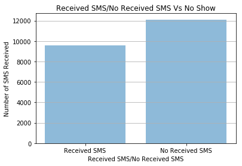

```python
#Plot a bar chart of Received/No Received Vs No Show
data=['Received SMS','No Received SMS']
plt.xticks([1,2], data)
x_pos = [1, 2]
heights = [9568,12112]
plt.bar(x_pos, heights,alpha=0.5)
plt.title('Received SMS/No Received SMS Vs No Show')
plt.xlabel('Received SMS/No Received SMS')
plt.ylabel('Number of SMS Received')
plt.grid(axis='y')
plt.show();
```

From the above chart, though a reasonable number of patients(about 9568) received sms prior to their appointments;most (about 12112) patients(about 12112) did not receive sms prior to their scheduled appointment.

## Research Question 6:Percentage of Female and Male Gender in the Dataset

```python
# Lets calculate the total number of females and males in the dataset
total_females = df['gender'].value_counts()['F']
total_males = df['gender'].value_counts()['M']
total = total_females + total_males
```

```python
#lets get the percentage of females and male in the dataset
per_of_females=(total_females/total)*100
Per_of_males=(total_males/total)*100
```

```python
#Percentage of Female and Male gender data
per_of_females,Per_of_males
```

```
(65.539125883276625, 34.460874116723375)
```

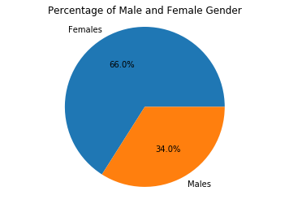

```python
#Lets plot a pie chart of gender in the dataset
sizes=[66,34]
labels='Females','Males'
plt.pie(sizes,labels=labels,autopct='%1.1f%%')
plt.title('Percentage of Male and Female Gender')
plt.axis('equal')
plt.show() ;
```

```python
from subprocess import call
call(['python', '-m', 'nbconvert', 'Investigate_a_Dataset.ipynb'])
```

```
0
```